# Project 1

# Part 1

The analysis that will be done below comes from a survey of participants at a conference in the Netherlands.

The participants were asked the following questions:

- What university do you come from?
- What is your position?
- How many employees are there in your research group?
- How many Ph.D. students are there in your research group?
- How many postdocs are there in your research group?
- How many professors are there in your research group?

All the answers are stored in a csv called survey.csv

The first action to do in any project is the loading of the required libraries.

```r
library(ggplot2)
library(readr)
library(dplyr)
library(lubridate)
library(tidyr)
```

Once the libraries are correctly installed, we can open the file with the data inside and store it in a meaningful variable.

```r
survey_data = read_csv("data/survey.csv")
```

```
## ──────────────────────────────────────────────────────── Delimiter: "," chr
## (3): University, Position, Sizes dbl (5): ...1, Number of employees, Number of
## PhD students, Number of postdo...
```

Once the dataset is loaded, we can see some metadata about it. The dataset has:

- “,” as a delimiter (which confirms that the columns are separeted by a commun in this text documet,)
- 30 rows
- 8 columns in total
  - 3 columns have categorical data (University, Position, Sizes)
  - 5 columns have numerical data (…1, Number of employees, Number of PhD students, Number of postdocs, Number of professors)

Looking at the columns name, one seems to have a strange name: “…1”

AS seen in the course, it is also always useful to get a first look at the head of the data and discover what does this strange column means in terms of data.

```r
head(survey_data,10)
```

| ...1 | University | Position | Number of employees | Number of PhD students | Number of postdocs | Number of professors | Sizes |
| --- | --- | --- | --- | --- | --- | --- | --- |
| 0 | Delft University of Technology | PhD Student | 15 | 4 | 6 | 5 | Small (1 to 20) |
| 1 | Eindhoven University of Technology | Head of department | 20 | 8 | 2 | 10 | Small (1 to 20) |
| 2 | Eindhoven University of Technology | Professor | 10 | 3 | 1 | 6 | Small (1 to 20) |
| 3 | Delft University of Technology | Assistant Professor | 191 | 120 | 47 | 24 | Extra large(over 200) |
| 4 | Delft University of Technology | Assistant Professor | 34 | 20 | 10 | 4 | Medium (20 to 50) |
| 5 | University of Groningen | Associate Professor | 79 | 33 | 13 | 33 | Medium (20 to 50) |
| 6 | University of Groningen | Head of graduate studies | 71 | 34 | 16 | 21 | Large (50 to 200) |
| 7 | Leiden University | Postdoc | 75 | 42 | 21 | 12 | Large (50 to 200) |
| 8 | Delft University of Technology | Postdoc | 54 | 28 | 14 | 12 | Large (50 to 200) |
| 9 | Delft University of Technology | Postdoc | 10 | 2 | 3 | 5 | Small (1 to 20) |

The column “…1” seems to be the index of the rows. Let’s rename it as index then. Let’s also rename the columns to remove the spaces between words.

```r
survey_data <- rename(survey_data,
       "Index" = "...1",
       "Number_of_employees" = "Number of employees",
       "Number_of_PhD_students" = "Number of PhD students",
       "Number_of_postdocs" = "Number of postdocs",
       "Number_of_professors" = "Number of professors")
```

## How many survey participants were there?

There are 30 participant to this survey.

## What are the top 3 universities with the most survey participants?

To answer this question, we will need to group by university, the count the row per university.

```r
survey_data %>%
  group_by(University) %>%
  mutate(Total = n()) %>%
  arrange(desc(Total)) %>%
  distinct(University, Total) %>%
  head(3) %>%
  ungroup()
```

| University | Total |
| --- | --- |
| Delft University of Technology | 9 |
| Eindhoven University of Technology | 7 |
| University of Groningen | 6 |

The top 3 of universities with the most survey participants are:

- Delft University of Technology
- Eindhoven University of Technology
- University of Groningen

# Part 2

Obtain a bar chart of the number of survey participants for the different positions given in the column Position.

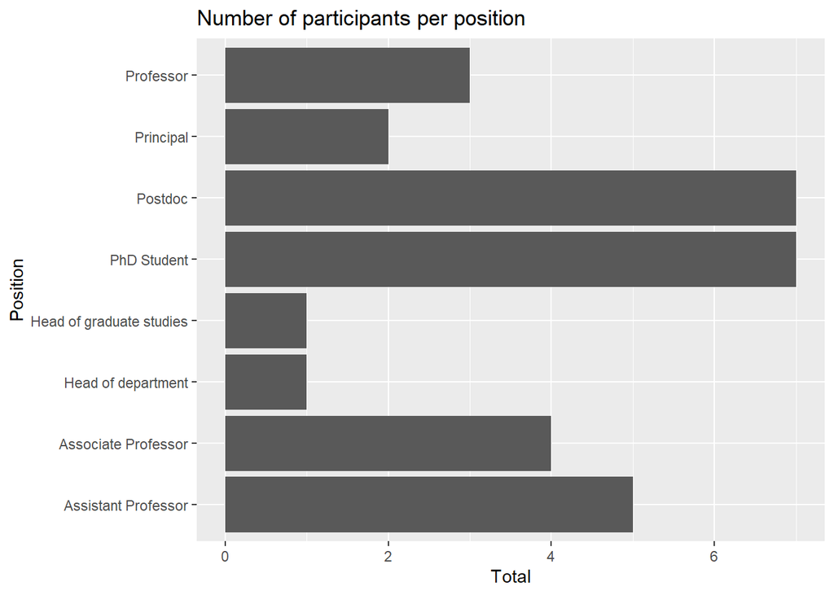

```r
position_table <- survey_data %>%
  group_by(Position) %>%
  mutate(Total = n()) %>%
  distinct(Position, Total)

ggplot(data = position_table,
       mapping = aes(x = Position,
                     y = Total))+
  geom_col() +
  coord_flip() +
  labs(title = "Number of participants per position")
```

# Part 3

There is a column named Sizes which depends on the number of the employees

There are some errors in this columns, so we need to correct it. First, we extract all the possibles values present in the column:

```r
survey_data %>%
  distinct(Sizes)
```

| Sizes |
| --- |
| Small (1 to 20) |
| Extra large(over 200) |
| Medium (20 to 50) |
| Large (50 to 200) |

Then, we create the same column correcting it:

[figure not shown]

```r
count_sizes <- survey_data %>%
  mutate(Sizes = case_when(
    Number_of_employees <= 20 ~ "Small (1 to 20)",
    Number_of_employees > 20 & Number_of_employees <= 50 ~ "Medium (20 to 50)",
    Number_of_employees > 50 & Number_of_employees < 200  ~ "Large (50 to 200)",
    Number_of_employees > 200 ~ "Extra large (over 200)"
  )) %>%
  select(Sizes) %>%
  group_by(Sizes) %>%
  mutate(count_sizes = n()) %>%
  distinct() %>%
  ungroup()

ggplot(data = count_sizes,
       mapping = aes(x = Sizes,
                     y = count_sizes))+
  geom_col() +
  coord_flip() +
  labs(title = "Number of participants per position")
```

# Part 4 Now, we need to see the percentage of employees who are Ph.D students, postdocs and professors.

[figure not shown]

```r
specie <- c(rep("sorgho" , 3) , rep("poacee" , 3) , rep("banana" , 3) , rep("triticum" , 3) )
condition <- rep(c("normal" , "stress" , "Nitrogen") , 4)
value <- abs(rnorm(12 , 0 , 15))
data <- data.frame(specie,condition,value)

ggplot(data, aes(fill=condition, y=value, x=specie)) +
    geom_bar(position="fill", stat="identity")
```

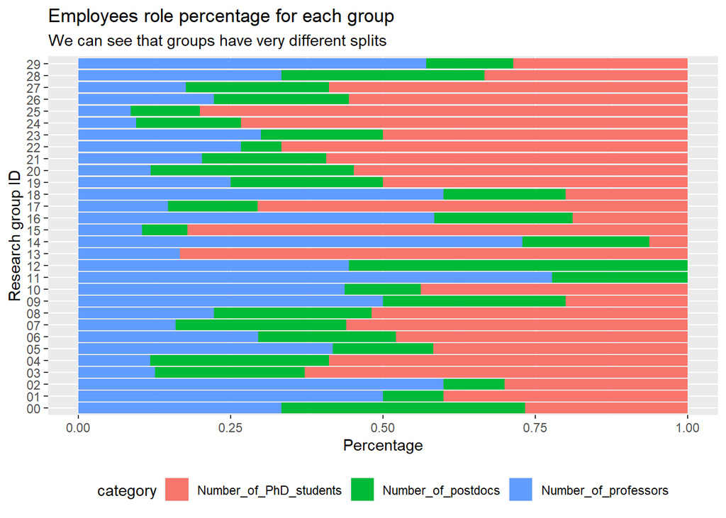

```r
survey_data <- transform(survey_data,Index = as.character(Index))

category_table <- survey_data %>%
  select(Index,Number_of_PhD_students,Number_of_postdocs,Number_of_professors) %>%
  pivot_longer(!Index,
               names_to = "category",
               values_to = "number") %>%
  mutate(Research_group_id = case_when(
    nchar(Index) == 1 ~ paste("0", Index, sep=""),
    TRUE ~ Index
  )) %>%
  arrange(desc(Research_group_id))

ggplot(category_table, aes(fill=category, y=number, x=Research_group_id)) +
    geom_bar(position="fill", stat="identity")+
    coord_flip()+
    labs(title = "Employees role percentage for each group",
       subtitle = "We can see that groups have very different splits",
       x = "Research group ID",
       y = "Percentage")+
    theme(legend.position="bottom")
```